# Which quantiles of a continuous distribution can one estimate with more precision?

Can LUO

9/22/2019

The median is an important quantity in data analysis. It represents the middle value of the data distribution. Estimates of the median, however, have a degree of uncertainty because

1. the estimates are calculated from a **finite sample**
2. the data distribution of the underlying data is generally unknown.

One important roles of a data scientist is to quantify and to communicate the degree of uncertainty in his or her data analysis. In this blog, I explained the answer to a series of questions related to the variation of the median (and a range of other quantiles) with various flexible functions.

# 1 Standard normal distribution

## 1.1 Medians

### 1.1.1 Density distribution

Let’s begin with the median from a sample of N = 200 from the standard normal distribution. Using the order statistic formula,I wrote an R function that is the density function for the median in this sample, and generated a plot of the function. Note that the 100th order statistic is approximately the median.

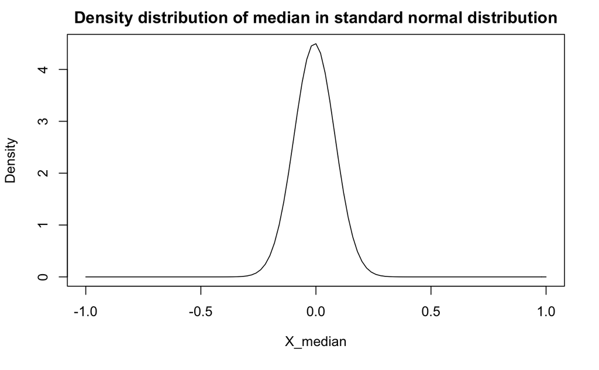

```r
dorder <- function(x,k=100,n=200){
  k*
  choose(n,k)*
  (pnorm(x))^(k-1)*
  (1-pnorm(x))^(n-k)*
  dnorm(x)
}
curve(
    dorder(x)
  ,-1
  ,1
  , xlab = parse(text="X_median")
  , ylab = "Density"
  ,main='Density distribution of median in standard normal distribution'
)
```

```r
NA
NA
NA
```

This is the theoretical plot of likelihood density of medians. Most of the density is located in range of (-0.3,0.3),and the highest point is laocated in x=0, which means for most situation, the variables should have median value between -0.3 to 0.3, very rarely it will be out of the range.

### 1.1.2 Probability distribution

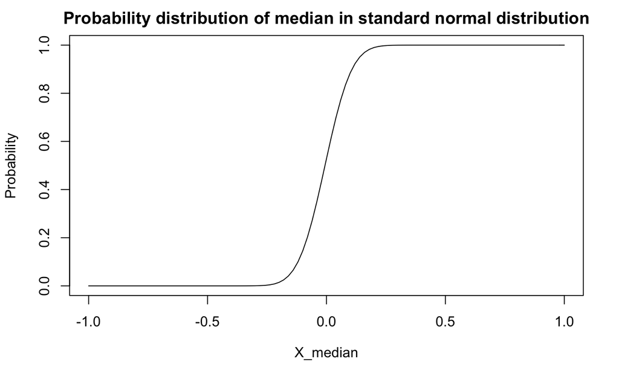

```r
porder <- function(x,k=100,n=200){
  pbinom(k-1, n, pnorm(x), lower.tail = FALSE)
}

curve(
    porder(x)
  , -1
  , 1
  , xlab = parse(text="X_median")
  , ylab = "Probability"
  ,main='Probability distribution of median in standard normal distribution'
)
```

Explanation of P and d function:

event A: In data of size n, the kth quantile is less than or equal to x0

event B: In data of size n, there have to be at least k variables less than or equal to x0. (the number of variables less than x0 > k-1)

event A and B are equivalent.

so we can calculate F(x) like this:

F(x)=P(event A)=P(event B)=pbinorm(k-1, n, pnorm(x), lower.tail = FALSE) #when lower.tail=False, return P[X > x]

then density function f(x) is the derivative of F(x).

### 1.1.3 Quantile distribution

The quantile function for the median in this sample is in the code below. (function ‘uniroot’ is the key point for producing ‘q’ function from ‘p’ function )

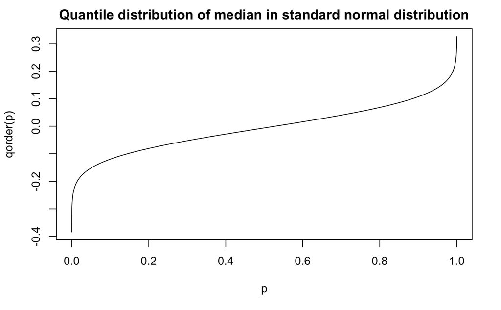

```r
qorder <- function(p,k=100,n=200){
  for (i in seq_along(p)){
  p[i]<-uniroot(function(q){porder(q,k,n)-p[i]},interval = c(-10,10))[[1]]
  }
  p
}

p<-seq(0.00001,1,0.0001)
plot(p,qorder(p),type='l' ,main='Quantile distribution of median in standard normal distribution')
```

### 1.1.4 ECDF

Then let’s simulate the sampling distribution for the median .The plot of the empirical CDF (ECDF)is as below.

```r
library(dplyr)
M <- 1000 # studies
N <- 200 # sample size
bmis <- array(rnorm(M*N), c(M, N))
medians <- bmis %>% apply(1, function(x){sort(x)[100]})

bmi_ecdf <- ecdf(medians)  # The output is a function
plot(bmi_ecdf, do.points = FALSE, col = "red", lwd = 3)
curve(porder(x), add = TRUE, lwd = 3, col = "blue")
```

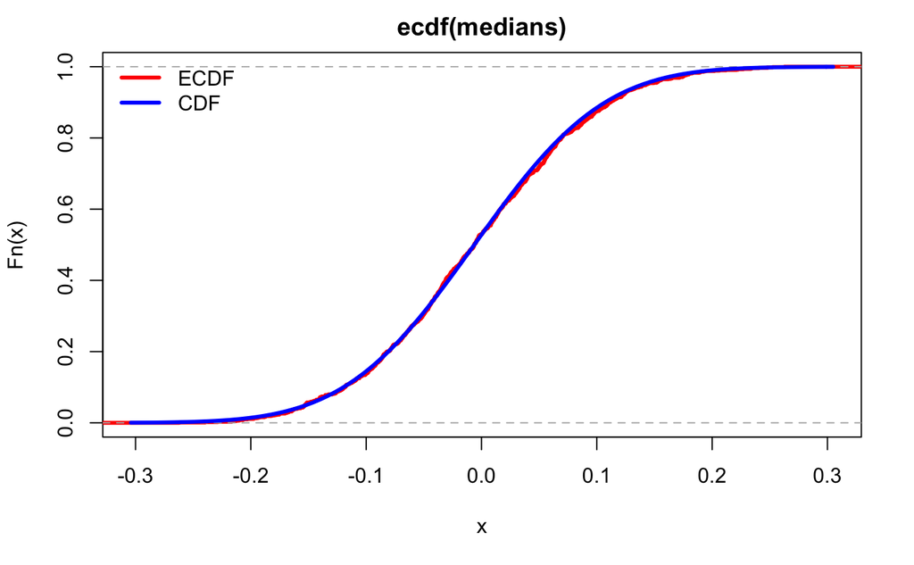

```r
legend(
    "topleft"
  , c("ECDF","CDF")
  , lwd = 3
  , col = c("red","blue")
  , bty = "n"
)
```

The curve of ECDF complies with curve of CDF, validating the approach of gennerating medians.

### 1.1.5 Density Histogram

Using the simulated sampling distribution from the previous question, I create a histogram (on the density scale) with a plot of the density function overlaying it.

```r
library(dplyr)

M <- 5000 # studies
N <- 200 # sample size
bmis <- array(rnorm(M*N), c(M, N))
medians <- bmis %>% apply(1, function(x){sort(x)[100]})
hist(medians, breaks = 100, freq = FALSE,main='Density distribution of theoretical and sampling medians')
curve(dorder(x), lwd = 3, add = TRUE, col = "blue")
```

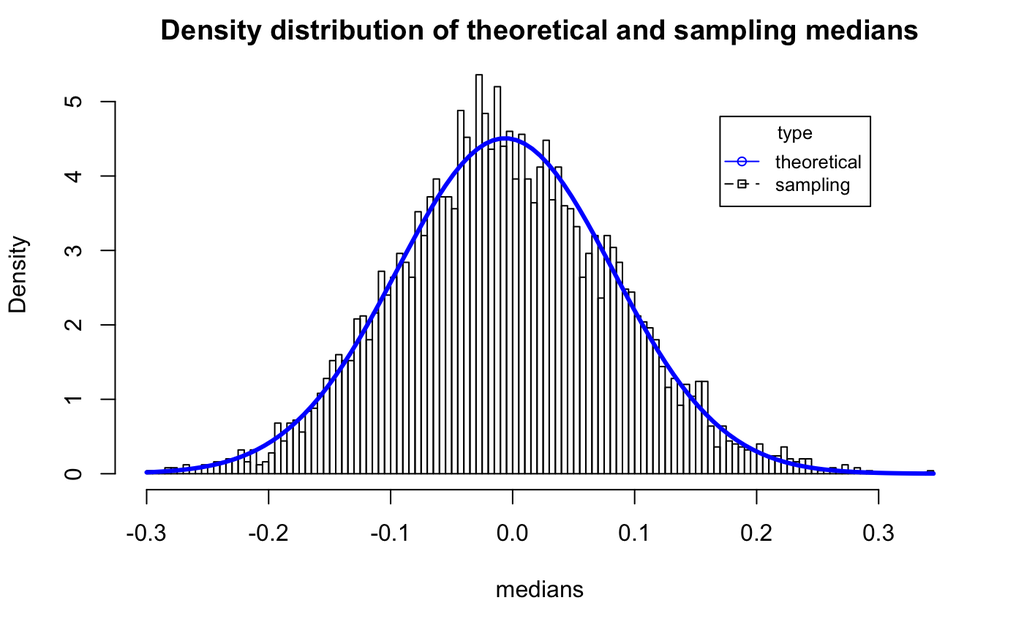

```r
legend(x=0.17,y=4.8,c('theoretical','sampling'),cex=0.8,col=c('blue','black'),pch=21:22, lty=1:2, bg="white", title="type", title.col="black")
```

We can see the sampling distribution is rougher than theoretical one, but in overall view they fit well.

### 1.1.6 QQplot

QQ plot is qunatile-quantile plot. For two series of variables, extract quantiles of equal probability values, and let them as x and y value to draw points. If two series of variables have same underlying distribution, the points should lie tightly close to the line of y=x. This plot can be applied to test the sampling accuracy by comparing with theretical quantiles.

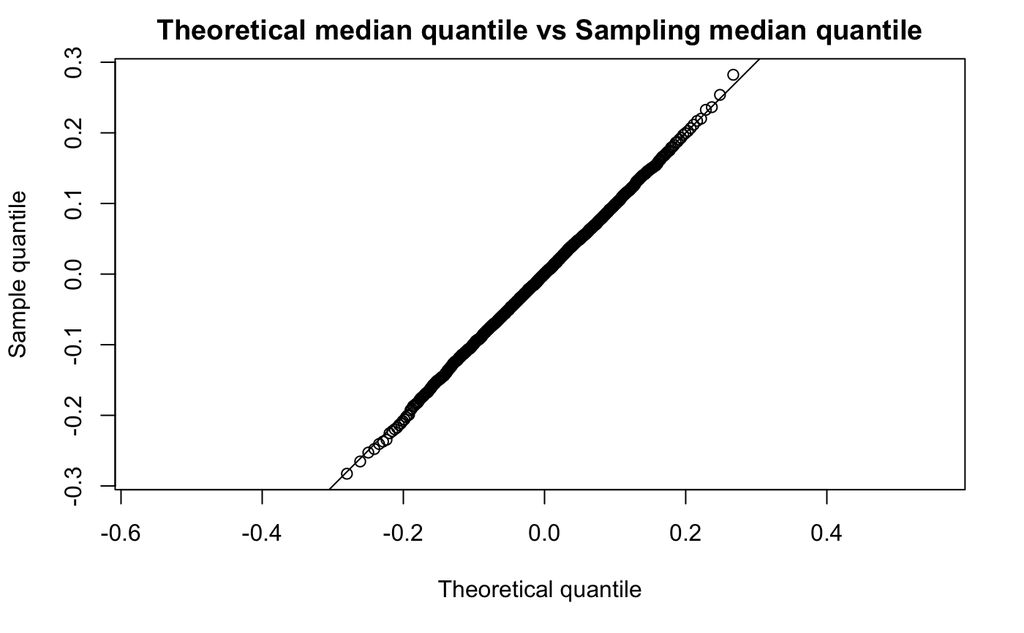

```r
M <- 5000 # studies
N <- 200 # sample size
bmis <- array(rnorm(M*N), c(M, N))
random_sample<- bmis %>% apply(1, function(x){sort(x)[100]})
q_candidate <- qorder

x <- q_candidate((1:999)/1000)
y <- quantile(random_sample, probs = (1:999)/1000)

plot(x,y, asp = 1,type='p',xlab = "Theoretical quantile", ylab = "Sample quantile",main='Theoretical median quantile vs Sampling median quantile')
abline(0,1)
```

From graph above, we can see theoretical quantiles has good linear relationship with sample quantile and the slope is equal to 1 intuitively, which means the sampling distribution of medians is faithful to underlying distribution.

## 1.2 Maximums

My qorder,porder,qorder functions have the default value of k and n. If we change the value of k or n, we can assign functions to work for any order statistic and not just the median.

```r
dorder <- function(x,k=100,n=200){
  k*
  choose(n,k)*
  (pnorm(x))^(k-1)*
  (1-pnorm(x))^(n-k)*
  dnorm(x)
}

porder <- function(x,k=100,n=200){
  pbinom(k-1, n, pnorm(x), lower.tail = FALSE)
}

qorder <- function(p,k=100,n=200){
  for (i in seq_along(p)){
  p[i]<-uniroot(function(q){porder(q,k,n)-p[i]},interval = c(-10,10))[[1]]
  }
  p
}
```

Changing the value of n and k, I generate a QQ plot for simulated data from the sampling distribution of the sample max and the theoretical largest order statistic distribution.

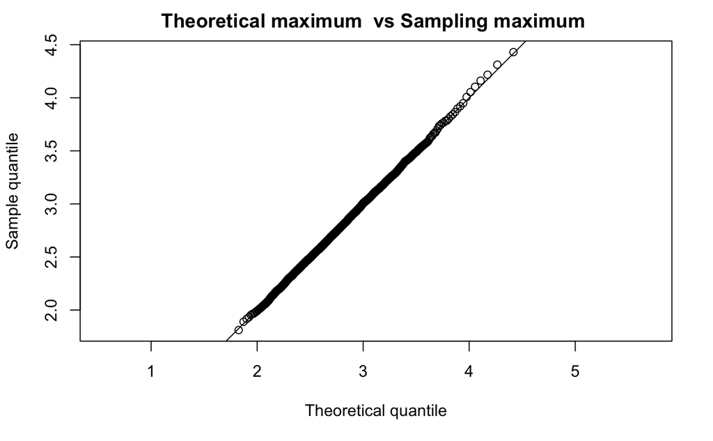

```r
M <- 5000 # studies
N <- 200 # sample size
bmis <- array(rnorm(M*N), c(M, N))
random_sample<- bmis %>% apply(1, function(x){sort(x)[200]})
q_candidate <- qorder
x <- q_candidate((1:1000)/1001,k=200)
y <- quantile(random_sample, probs = (1:1000)/1001)
plot(x,y, asp = 1,type='p',xlab = "Theoretical quantile", ylab = "Sample quantile",main='Theoretical maximum  vs Sampling maximum ')
abline(0,1)
```

From graph above,we can tell sampling distribution of maximum fits well with theoretical distribution.

The middle part of distribution of standard norm is sharp while the end part is flattern.

```r
curve(dnorm(x)
      ,-5
      ,5)
abline(v=c(0,0.3),col='red',lty=2)
```

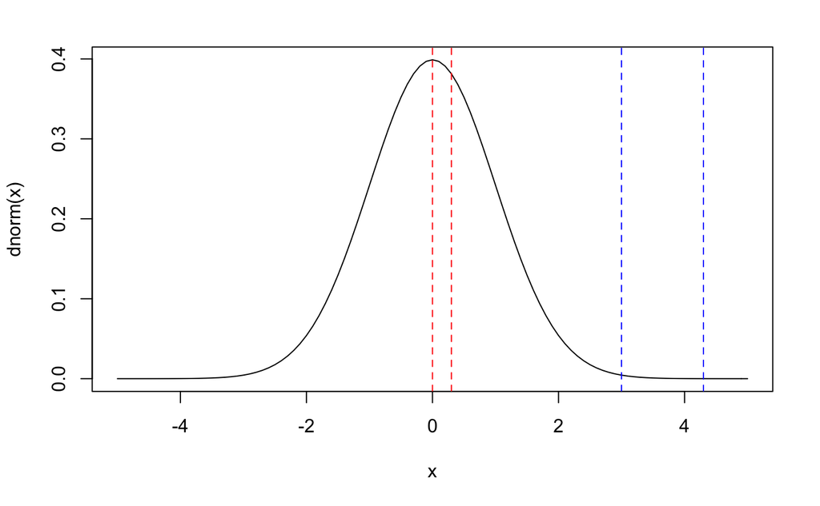

```r
abline(v=c(3,4.3),col='blue',lty=2)
```

```r
diff(dnorm(c(4.3,3)))
```

```
[1] 0.004393313
```

```r
diff(dnorm(c(0.3,0)))
```

```
[1] 0.01755446
```

The likelihood difference between x=0 and x=0.3 is 0.01755, that between x=3 and x=4.3 is 0.0043933. So in the end part, from x=3 to x=4.3, they have nearly the same likelihood to be the maximum, so the sampling distribution of maximum shoulbe be wider. But for median, the likelihood difference are bigger, so the value around the true median are less likely to appear, so the sampling distribution are sharper.

# 2 Exponential distribution

Based on the recycling principle, we ‘recycle’ the functions by adding new parameters ‘dist’ to them, so that they can be applied to other continuous distributions.

```r
dorder_f <- function(x,k=1,n=200,dist,...){
  PFUN<-get(paste0('p',dist))
  DFUN<-get(paste0('d',dist))
  k*
  choose(n,k)*
  (PFUN(x,...))^(k-1)*
  (1-PFUN(x,...))^(n-k)*
  DFUN(x,...)
}


porder_f <- function(x,k=1,n=200,dist,...){
  PFUN<-get(paste0('p',dist))
  pbinom(k-1, n, PFUN(x,...), lower.tail = FALSE)
}

qorder_f <- function(p,k=1,n=200,dist,...){
  for (i in seq_along(p)){
  p[i]<-uniroot(function(q){porder_f(q,k,n,dist,...)-p[i]},interval = c(-1,1))[[1]]
  }
  p
}
```

## 2.1 Minimums

Using the newly modified functions , I plot the probability and density functions for the sample min (N = 200) of exponential distribution.

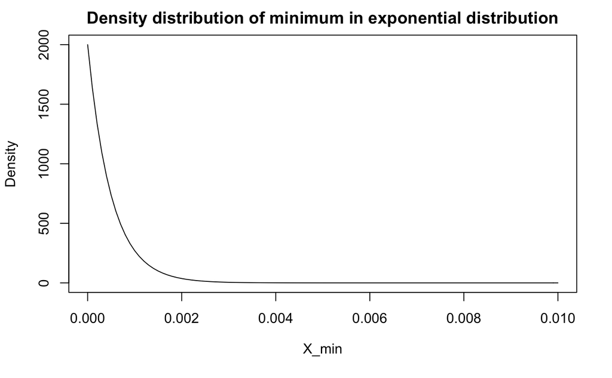

The minimum of exponential distribution(rate=10) has very tight distribution, one-sided close to 0.

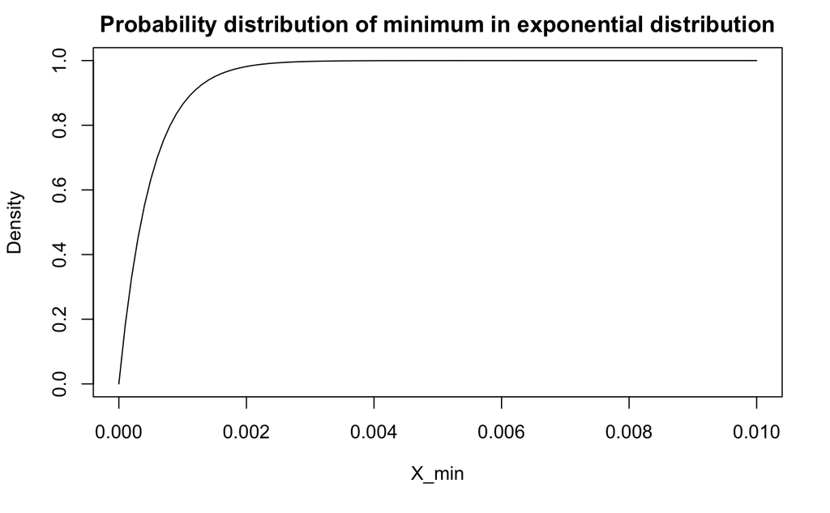

From the probability distribution, the probability is more than 90% that the minimum of that exponential distribution of size 200 is less than 0.002. So we can roughly assume the minimum are always near 0.